# data-analysis-replication

Matt Ming

4/14/2022

# 1. Introduction

## 1.1 Background

The goal of this replication project is to reproduce as accurately as possible the figures in the paper “*Dispersal patterns in black howler monkeys* *(Alouatta pigra): Integrating multiyear demographic and molecular data*” by Sarie Van Belle and Anthony Di Fiore in 2021 (Molecular Ecology).

This paper focuses on examining dispersal patterns in howler monkeys in a region of Mexico. Animal dispersal is hypothesized to present benefits in the form of reduction of both inbreeding and kin competition, but comes at the cost of potentially delayed reproductive access or decreased survival of the individual and its offspring. Dispersal patterns between the sexes vary greatly between species, with some species showing *bisexual dispersal* where both sexes will disperse with equal frequency from their natal groups (the groups they were born into), while some species show *sex-biased dispersal* where individuals of one sex disperse with greater frequency than individuals of the other sex. Complicating matters further is the spectrum of dispersals seen in nature, where some combination of bisexual and sex-biased dispersal to varying degrees may be observed even within one group or set of groups, as well as the difficulty of studying dispersal patterns in the wild. However, genetic analyses of population substructure may provide insight into dispersal patterns, as the genetic variation between subgroups in each sex can shed insight into the frequency with which each sex emigrates. Black howler monkeys (*Alouatta pigra*) are a good study system because there have been observed instances of bisexual dispersal, but the degree of male-female dispersal patterns is unknown.

This paper uses a genetic dataset collected from study of several groups of howler monkeys in Palenque National Park, Mexico from 2006-2007 and 2010-2020. Genetic data was collected from faecal samples, and individuals were genotyped by either 18 or 21 polymorphic microsatellite markers. The general assertion is that a match at all genomic markers represents the same individual, so finding genetic evidence of one individual in two different group ranges at two different times would be evidence of a dispersal event.

## 1.2 Original Analyses Conducted

Four main analyses were conducted in the original paper.

- First, dispersal events were recorded and quantified, identifying which individuals left their natal group, what groups they emigrated from and immigrated into, and how many males and females dispersed
- Second, global $\small F_{ST}$—a statistical measure of variation between subgroups—is calculated separately for males and females for adult individuals in 18 groups. This is to get a sense of genetic variation between subgroups, and if this variation differs between sexes. Small differences in $\small F_{ST}$ values should indicate similar rates of dispersal in males and females.
- Third, spatial autocorrelation was conducted which would show if increased geographical distance correlated with increased genetic variance (measured as $\small F_{ST}/(1-F_{ST})$). The null expectation is that this should be the case.
- Fourth, mean pairwise relatedness of individuals within groups was compared to relatedness between groups. The expectation here is that low dispersal rates would lead to high difference between within and between group relatedness while high dispersal rates would lead to low difference, and that differences in dispersal rate between males and females should be reflected in the difference in relatednesses between the sexes.

## 1.3 Analyses Reproduced

For this project, I will reproduce the second, third, and fourth analyses. I will not be reproducing the geographic group ranges or dispersal figures (**Fig1** and **Fig2**) because this analysis was more descriptive than qualitative and the information about dispersal events was not included in the data files (it is included in **S Table2** but this is based on observation and not reproducible).

## 1.4 Formatting notes

Figures and tables in the original paper are denoted in **bold**.

Data files are denoted in *italics*.

R packages, R functions, and outside software are denoted using `code font`.

Throughout the R code, there are commented-out lines with `cat("XXX")`. These lines were simply used to keep track of the progress of long-running code chunks, and can be ignored. They may also be un-commented to help provide a sort of progress tracker when running the code locally.

# 2. Results of Replications

## 2.0 Initializing Data

To initialize, I will need to load in all of the following packages, as well as include code to allow `knitr` to know where to find the images used from the original paper.

I will also read in all of the data files for this project. There are four data tables publicly available for this paper, and I use all four in this project.

- *Adults2012.xlsx* gives a list of the 65 adult monkeys sampled in 2012 which were used for the majority of analyses, their sex, and the group to which they belong
- *GenotypeData_Dryad.csv* gives the genotype of all individuals sampled from all time periods. The genotypes are given as “alleleA/alleleB” and represent repeat counts for 21 microsatellite loci across the genome
- *GeographicCoordinates.csv* gives the coordinates of the centroid of all home groups observed in 2012, and includes all home groups to which the adults used for the analyses belonged
- *PairwiseRelatedness_allAdultDyads_2012.xlsx* gives a list of all pairwise comparisons of two adult individuals, including their relatedness as calculated using the Queller-Goodnight estimator, their sexes, and the home group to which they belonged

```r
adults <- read_excel("./data/Adults2012.xlsx")
gen <- read.csv("./data/GenotypeData_Dryad.csv")
coords <- read.csv("./data/GeographicCoordinates.csv")
rel <- read_excel("./data/PairwiseRelatedness_allAdultDyads_2012.xlsx")
```

We can view a preview of each of these files to get a sense of the format of the data, the column names, etc. using the head function, as below:

```r
head(adults)
```

```
## # A tibble: 6 x 3
##   Ind        Sex   Grp
##   <chr>      <chr> <chr>
## 1 BAL-LU-59  F     BAL
## 2 BAL-TE-78  F     BAL
## 3 BAL-KR-79  M     BAL
## 4 BAL-GZ-60  M     BAL
## 5 BOL-AO-198 F     BOL
## 6 BOL-DK-194 F     BOL
```

```r
head(gen)
```

```
##   Individual Group Year.Collected N.Loci AB.06   AB.17 AP68    AP74   Api07
## 1      Balam BALAM           2007     17   0/0 224/240  0/0 169/171     0/0
## 2       Batz BALAM           2007     16   0/0 224/224  0/0 169/169 136/140
## 3      Bruna BALAM           2007     17   0/0 224/244  0/0 169/169 140/140
## 4        Guz BALAM           2007     18   0/0 224/244  0/0 169/169 134/140
## 5      Kriek BALAM           2007     18   0/0 224/244  0/0 169/171 140/140
## 6      Louie BALAM           2007     18   0/0 228/228  0/0 171/171 130/134
##     Api14   Apm01  Ceb120 D17S804  D5S111 D6S260  D8S165  D8S260  Leon.2
## 1 233/233 180/208 233/253 158/162 166/178    0/0 116/139 208/208 184/188
## 2     0/0 199/199 253/253 158/158 166/166    0/0 116/116 208/208 184/188
## 3 225/225 182/182 233/233 158/158 166/178    0/0 116/139 208/208 188/188
## 4 200/225 182/199 233/253 158/158 166/178    0/0 116/139 208/208 186/188
## 5 200/225 182/199 253/253 158/158 166/178    0/0 116/139 208/208 182/184
## 6 200/225 180/208 253/257 154/162 166/178    0/0 116/116 208/208 182/182
##   Leon.31 LL.1.1.10 LL.1.1.15 LL.1.1.3 LL.1.5.7 Locus.5   SB.30
## 1 285/285   199/201   209/227  181/181  208/210  91/108 101/101
## 2 285/285       0/0   201/212  169/183  208/210  95/108 101/101
## 3     0/0   199/202   205/209  179/181  208/208 102/107 103/105
## 4 285/287   199/203   212/216  181/183  210/210  95/108 101/103
## 5 285/285   199/203   201/209  181/183  208/210   91/95 101/103
## 6 287/287   188/199   209/209  181/183  208/208   80/91 101/101
```

```r
head(coords)
```

```
##     Group      X       Y
## 1 MOTIEPA 600887 1933776
## 2  UNITES 600899 1933328
## 3   PAKAL 600716 1933493
## 4   BOLAS 600534 1933724
## 5   BALAM 600502 1933511
## 6     BRA 601517 1933736
```

```r
head(rel)
```

```
## # A tibble: 6 x 11
##   RowID IND1        IND2        QGR SEX1  SEX2  SexDyadType Grp1  Grp2  GrpCombo
##   <dbl> <chr>       <chr>     <dbl> <chr> <chr> <chr>       <chr> <chr> <chr>
## 1     1 BAL-LU-59   BAL-TE-~  0.39  F     F     FF          BAL   BAL   BAL-BAL
## 2     2 NAH-ZT-299  NAH-AM1~  0.58  F     M     MF          NAH   NAH   NAH-NAH
## 3     3 NAH-ZT-299  NAH-LI-~ -0.083 F     M     MF          NAH   NAH   NAH-NAH
## 4     4 CAL-AF1-121 TC2-AF1~ -0.126 F     F     FF          CAL   TC2   CAL-TC2
## 5     5 CAL-AF2-122 TC2-AF1~ -0.128 F     F     FF          CAL   TC2   CAL-TC2
## 6     6 CAL-AM1-114 TC2-AF1~ -0.156 M     F     MF          CAL   TC2   CAL-TC2
## # ... with 1 more variable: GrpDyadType <chr>
```

Some data cleaning:

- The “BALAM” group was coded as both “BALAM” and “Balam” in the *GenotypeData_Dryad.csv* file, so all groups were made to be all uppercase to keep things consistent
- The individual “AM1-PAK” was listed twice in the *GenotypeData_Dryad.csv* file, even though the genotypes listed were different, so the second individual labeled “AM1-PAK” was changed to “AM2-PAK”
- Some individuals were listed twice in the *GenotypeData_Dryad.csv* because they were sampled in different years, but their genotypes were the same (indicating these entries were all the same individual) so only the last entry of each individual was kept to reduce redundancy

```r
gen$Group <- toupper(gen$Group)
gen$Individual[109] <- "AM2-PAK"
gen <- gen[-which(duplicated(gen$Individual,fromLast = TRUE)),]
```

All other tables were checked and confirmed for correctness.

## 2.1 Global $\small F_{ST}$

$\small F_{ST}$ is calculated using the `FSTAT` program, which uses the Weir-Cockerham $\small F_{ST}$ estimator.

For multiple sub-population samples with differing sample sizes and multiple alleles at each locus, the Weir-Cockerham $\small F_{ST}$ (denoted in their paper as $\small \hat{\theta}$) is calculated as

$$\hat{\theta}_W = \frac{\sum_u{a_u}}{\sum_u{(a_u + b_u + c_u)}}$$

Where $u$ is each allele and

$$a = \frac{\bar{n}}{n_c}
\{S^2 - \frac{1}{\bar{n}-1}
[\bar{p}(1-\bar{p}) - \frac{r-1}{r}S^2 - \frac{1}{4}\bar{h}]\}$$

$$b = \frac{\bar{n}}{\bar{n}-1}
[\bar{p}(1-\bar{p}) - \frac{r-1}{r}S^2-\frac{2\bar{n}-1}{4\bar{n}}\bar{h}]$$

$$c = \frac{1}{2}\bar{h}$$

where

- $\tilde{p}_i$ is the observed frequency of allele $u$ in the sample from sub-population $i$
- $n_i$ is the size of sample $i$
- $\tilde{h}_i$ is the observed frequency of heterozygotes for allele $u$
- $\bar{n} = \sum_{i}{n_i/r}$, the average sample size
- $n_c = (r\bar{n} - \sum_{i}{n_i^2/r\bar{n}})/(r-1)$
- $\bar{p} = \sum_i{n_i\tilde{p}_i/r\bar{n}}$, the average sample frequency of allele $u$
- $S^2 = \sum_i{n_i(\tilde{p}_i-\bar{p})^2/(r-1)\bar{n}}$, the sample variance of allele $u$ frequencies over populations
- $\bar{h} = \sum_i{n_i\tilde{h}_i/r\bar{n}}$, the average heterozygote frequency for allele $u$

To begin this analysis, only adults in the 18 study groups sampled from in 2012, which are the individuals and groups listed in the *Adults2012.xlsx*. This meant that I had to reduce the *GenotypeData_Dryad.csv* to only those individuals who are listed in the *Adults2012.xlsx*, which I store as a new dataframe. These individuals were simply identified manually by their ID in *Adults2012.xlsx*.

```r
a_names <- c("Luz","Teresa","Kriek","Guz","Anon","Dinka","Puma","Rafiki",
            "BRA-AF","BRA-AM","CAL-AF1","CAL-AF2","CAL-AM1","CAL-AM2","CRU-AF1",
            "CRU-AF2","CRU-AM","JAG-AF1","JAG-AF2","JAG-AM1","JAG-AM2","MBL-AF1",
            "MBL-AF2","MBL-AM1","MBL-AM2","MDK-AF","MDK-AM","Isa","Melanie",
            "Hugo","Jupiler","MUS-AF","MUS-AM","Zita","NAH-AF1","NAH-AM1","Lineo",
            "Emma","Esa","Parcha","Pura","Roco","Sibal","PIG-AF1","PIG-AF2",
            "PIG-AM1","PIG-AM2","TC2-AF1","TC2-AF2","TC2-AM","TNO-AF1","TNO-AF2",
            "TNO-AM1","TNO-AM2","TNO-AM3","TOL-AF1","TOL-AF2","TOL-AM","Galena",
            "Lola","Mona","Boquinche","Dinde","WPS-AF","WPS-AM")
gen_a <- gen %>% filter(Individual %in% a_names)
gen_a <- gen_a[order(match(gen_a$Individual,a_names)),]
gen_a$Sex <- adults$Sex
gen_a$Group[which(gen_a$Individual == "Pura")] <- "PAKAL"
gen_a$Group[which(gen_a$Group == "NAH")] <- "NAHA"
gen_a <- gen_a[order(gen_a$Group),]
gen_test <- gen_a
```

I will also be using the `wc()` function from the `hierfstat` package, which computes the Weir-Cockerham $\small F_{ST}$ estimate. To use this function, I need to have a dataframe which consists of a column of the sub-populations (as numeric factors) as well as one column per locus, with the alleles coded as numeric factors (next to each other, without any characters in between, e.g., “272/272” = 11, “272/280” = 12).

```r
# Converting all genotypes for all loci to the appropriate format for wc()
for(l in 5:25){
  alleles <- data.frame(A = unlist(strsplit(gen_a[[l]],"[/]"))[c(TRUE,FALSE)],
                        B = unlist(strsplit(gen_a[[l]],"[/]"))[c(FALSE,TRUE)])
  alleles$a <- as.numeric(factor(alleles$A,
                                 levels = unique(c(alleles$A,alleles$B))))
  alleles$b <- as.numeric(factor(alleles$B,
                                 levels = unique(c(alleles$A,alleles$B))))
  gen_a[[l]] <- as.numeric(paste0(alleles$a,alleles$b))
}
gen_a$Group <- as.numeric(factor(gen_a$Group))

# Splitting adult data by sex
gen_f <- gen_a %>% filter(Sex == "F") %>% select(c(2,5:25))
gen_m <- gen_a %>% filter(Sex == "M") %>% select(c(2,5:25))

# Using the wc() function
FST_f <- wc(gen_f)$FST
FST_m <- wc(gen_m)$FST

cat("\nGlobal Female FST Estimate =",FST_f)
```

```
##
## Global Female FST Estimate = 0.1698231
```

```r
cat("\nGlobal Male FST Estimate   =",FST_m,"\n")
```

```
##
## Global Male FST Estimate   = 0.1231817
```

Confidence intervals can be found, following `FSTAT` documentation, by performing a bootstrap by randomizing loci (as long as there are 4 or more loci, here we have 21 loci) by resampling n loci with replacement. I performed 1,000 bootstrap replicates.

```r
FSTCI <- function(df,alpha){
  # Function to get confidence intervals for estimates of FST for a given set of
  # genotype data by repeatedly re-samples all loci

  # Arguments:
  # df = dataframe containing genotype information
  # alpha = confidence interval cut-off

  # Output:
  # Print to console of confidence intervals for females and males

  boot <- rep(NA,1000)
  for(i in 1:1000){
    set.seed(i)
    # cat("\rBootstrap Rep ",i,"/1000",sep = "")
    resamp <- df[,c(1,sample(2:22,replace = TRUE))]
    boot[i] <- wc(resamp)$FST
  }
  return(boot)
}

f_boot <- FSTCI(gen_f,0.05)
m_boot <- FSTCI(gen_m,0.05)

f_CI95 <- quantile(f_boot,c(0.025,0.975))
m_CI95 <- quantile(m_boot,c(0.025,0.975))

cat("\nGlobal Female FST 95% CI =",f_CI95[1],"-",f_CI95[2])
```

```
##
## Global Female FST 95% CI = 0.1363406 - 0.2039039
```

```r
cat("\nGlobal Male FST 95% CI   =",m_CI95[1],"-",m_CI95[2])
```

```
##
## Global Male FST 95% CI   = 0.08143469 - 0.1643223
```

I also calculated global $\small F_{ST}$ by hand by following the above equations

```r
FST <- c(NA,NA)
names(FST) <- c("F","M")

# Calculate FST manually using equations from Weir-Cockerham (1984)

# Loop over each sex
for(s in names(FST)){
  # cat("\nCurrent Sex",s,"\n\n")
  gen_s <- gen_test %>% filter(Sex == s)
  numerl <- c()
  denoml <- c()
  r <- length(unique(gen_s$Group))

  # Loop over all loci
  for(l in 5:25){
    numeru <- c()
    denomu <- c()
    # cat("\rCompleted Locus ",l-4,"/21",sep = "")
    genotypes <- data.frame(I = gen_s$Individual,
                            A = unlist(strsplit(gen_s[[l]],"[/]"))[c(TRUE,FALSE)],
                            B = unlist(strsplit(gen_s[[l]],"[/]"))[c(FALSE,TRUE)])

    # Loop over all alleles in each locus
    for(u in unique(c(genotypes$A,genotypes$B))){
      ni <- rep(NA,r)
      pi <- rep(NA,r)
      hi <- rep(NA,r)
      for(g in 1:r){
        gen_i <- genotypes[which(gen_s$Group == unique(gen_s$Group)[g]),]
        ni[g] <- nrow(gen_i)
        pi[g] <- length(which(c(gen_i$A,gen_i$B) == u))/length(c(gen_i$A,gen_i$B))
        hi[g] <- gen_i %>% filter((A == u | B == u) & (A != B)) %>%
          nrow()/length(gen_i$A)
      }
      nbar <- sum(ni/r)
      nc <- ((r*nbar) - sum((ni^2)/(r*nbar)))/(r-1)
      pbar <- sum((ni*pi)/(r*nbar))
      s2 <- sum((ni*((pi - pbar)^2))/((r-1)*nbar))
      hbar <- sum((ni*hi)/(r*nbar))

      a <- (nbar/nc)*
        (s2 -
           ((1/(nbar-1))*
              ((pbar*(1-pbar)) -
                 (((r-1)/r)*s2) -
                 (hbar/4)
               )
            )
         )
      b <- (nbar/(nbar-1))*
        ((pbar*(1-pbar)) -
           (((r-1)/r)*s2) -
           ((((2*nbar)-1)/(4*nbar))*hbar)
         )
      c <- hbar/2

      d <- a+b+c

      numeru <- c(numeru,a)
      denomu <- c(denomu,d)
    }
    numerl <- c(numerl,sum(numeru))
    denoml <- c(denoml,sum(denomu))
  }
  FST[s] <- sum(numerl)/sum(denoml)
  # cat("\n\n------------------------------------------------\n")
}

cat("\nGlobal Female FST Estimate =",FST["F"])
```

```
##
## Global Female FST Estimate = 0.1698231
```

```r
cat("\nGlobal Male FST Estimate   =",FST["M"],"\n")
```

```
##
## Global Male FST Estimate   = 0.1231817
```

Both of these methods yielded the same results, confirming the veracity of both. However, neither of these results exactly completely matched the results reported in the original paper, although they are close

- Original Female $\small F_{ST} = 0.164$, CI 0.137 - 0.213; reproduced Female $\small F_{ST} = 0.170$, CI 0.136 - 0.203
- Original Male $\small F_{ST} = 0.118$, CI 0.072 - 0.156; reproduced Male $\small F_{ST} = 0.123$), CI 0.0814 - 0.164.

To reproduce the replication to determine the p-values of each of these $\small F_{ST}$ values, I performed a sex-randomization permutation test as described in the text from `FSTAT`. The process for this involves using the same global genotype table as was used to find the $\small F_{ST}$ but with the sex column randomized each time. This is replicated for 10,000 replications. Below, histograms show the Null Distributions of male and female $\small F_{ST}$ with the red line indicating where the estimated $\small F_{ST}$ falls.

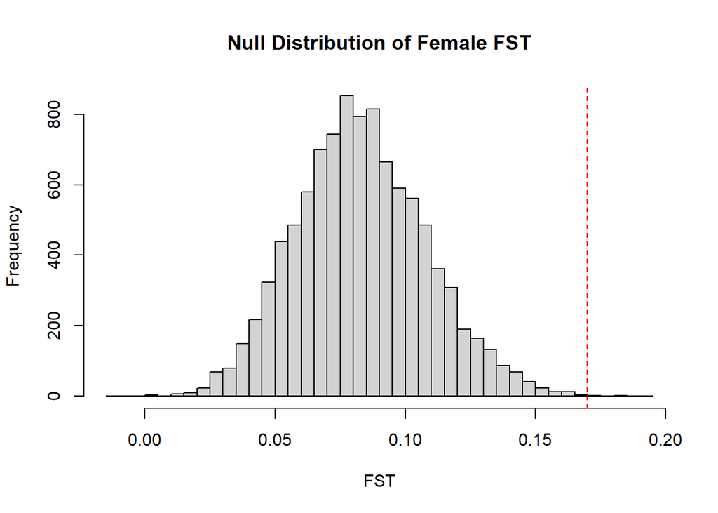

```r
nulldistF <- rep(NA,10000)
nulldistM <- rep(NA,10000)
gen_rand <- gen_a

# Get null distributions for FST estimates for males and females

# Permute 10,000 times
for(i in 1:10000){
  set.seed(i) # Set seed for replicability
  # cat("\rPermutation Rep ",i,"/10000",sep = "")
  gen_rand$Sex <- sample(gen_rand$Sex)
  nulldistF[i] <- wc(gen_rand[which(gen_rand$Sex == "F"),c(2,5:25)])$FST
  nulldistM[i] <- wc(gen_rand[which(gen_rand$Sex == "M"),c(2,5:25)])$FST
}

# Get histograms of null distributions
hist(nulldistF,breaks = 30,main = "Null Distribution of Female FST",
     xlab = "FST")
abline(v = FST_f,col = "red",lty = "dashed")
```

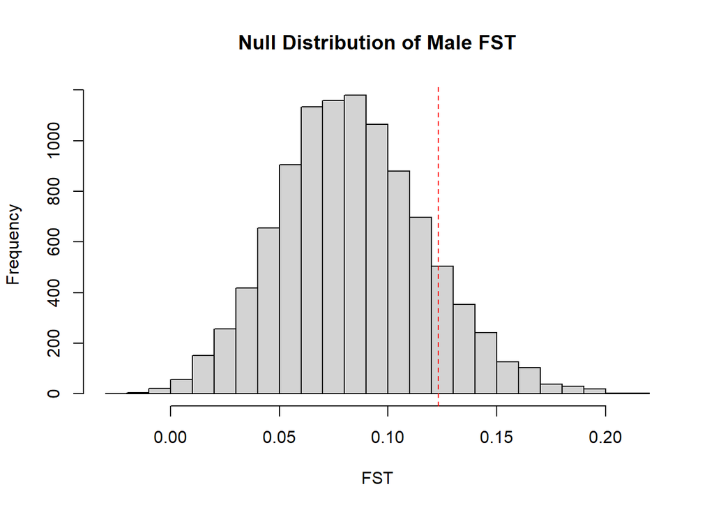

```r
hist(nulldistM,breaks = 30,main = "Null Distribution of Male FST",
     xlab = "FST")
abline(v = FST_m,col = "red",lty = "dashed")
```

```r
# Get p-values for estimated FST vs Null
pval_f <- sum(length(which(nulldistF < -abs(FST_f))),
              length(which(nulldistF > abs(FST_f))))/10000
pval_m <- sum(length(which(nulldistM < -abs(FST_m))),
              length(which(nulldistM > abs(FST_m))))/10000
cat("\nGlobal Female FST p-value =",pval_f)
```

```
##
## Global Female FST p-value = 5e-04
```

```r
cat("\nGlobal Male FST p-value   =",pval_m,"\n")
```

```
##
## Global Male FST p-value   = 0.1262
```

Interestingly, this analysis revealed that of the two $\small F_{ST}$ values, only the female $\small F_{ST}$ was significant, while the male $\small F_{ST}$ was not; this is different from the original analysis which concluded that both of these estimates were significant. Given that the actual values for $\small F_{ST}$ were similar between replicated and original, I am unsure why the significance should be so different.

We can get level of significance between Male and Female $\small F_{ST}$ values by seeing how much overlap there is between the bootstrapped distributions for each sex, specifically how much overlap there is of the 95% confidence intervals.

```r
# Compare FST estimates between sexes
pval_fm <- (length(which(f_boot < quantile(m_boot,0.975))) +
              length(which(m_boot > quantile(f_boot,0.025))))/
  length(c(f_boot,m_boot))

cat("The p-value between each sex-specific FST =",pval_fm)
```

```
## The p-value between each sex-specific FST = 0.324
```

This test confirms that the $\small F_{ST}$ values for each sex do not differ significantly from each other (p-value = 0.324). This p-value is fairly similar to the between-sex $\small F_{ST}$ p-value found in the original paper.

## 2.2 Spatial Autocorrelation

To perform spatial autocorrelation analysis, I generated group-based pairwise $\small F_{ST}$ calculations (i.e., $\small F_{ST}$ calculated between two different groups, for all pairs of groups) as opposed to the global $\small F_{ST}$ from the previous step which took all groups into account simultaneously. This can be achieved by using the same genotype table as before but this time subsetting by only the individuals from two different groups and looping over all of the group pairs. Again, only adult individuals from the groups sampled in 2012 are considered.

However, because of the structure of the populations and the fact that some pairwise population comparisons have only one individual per population in one or both of the sexes, the WC estimator is not quite accurate for estimating $\small F_{ST}$. Therefore, for this step I switch to a different $\small F_{ST}$ estimator which uses observed allele frequencies to generate estimates of heterozygozity, giving $\small F_{ST} = \frac{H_T - \bar{H}_e}{H_T}$

```r
calcFST <- function(df,p1,p2){
  # Function to calculate FST using the heterozygozity estimate equations

  # Arguments
  # df = dataframe containing genotype data
  # p1 = first pairwise population
  # p2 = second pairwise population

  # Outputs
  # FST estimate

  HT <- c()
  He1 <- c()
  He2 <- c()

  # Looping over all loci
  for(l in 5:25){
    p1g <- as.character(df[which(df[["Group"]] == p1),l])
    p2g <- as.character(df[which(df[["Group"]] == p2),l])
    p1a <- unlist(strsplit(p1g,""))
    p2a <- unlist(strsplit(p2g,""))
    uniqa <- unique(c(p1a,p2a))
    He1i <- 0
    He2i <- 0
    HTi <- 0

    # Looping over all alleles for each locus
    for(a in uniqa){
      pa1 <- length(which(p1a == a))/length(p1a)
      pa2 <- length(which(p2a == a))/length(p2a)
      pTa <- length(which(c(p1a,p2a) == a))/length(c(p1a,p2a))
      He1i <- He1i + (pa1^2)
      He2i <- He2i + (pa2^2)
      HTi <- HTi + (pTa^2)
    }
    He1 <- c(He1,He1i)
    He2 <- c(He2,He2i)
    HT <- c(HT,HTi)
  }
  HT <- 1 - HT
  He1 <- 1 - He1
  He2 <- 1 - He2
  Hebar <- (He1/2) + (He2/2)
  num <- HT - Hebar
  FST <- sum(num)/sum(HT)
  return(FST)
}

# Running above function
FSTlist <- list(F = c(),M = c(),pop1 = c(),pop2 = c())
for(s in c("F","M")){
  done <- c()
  gen_s <- gen_a %>% filter(Sex == s)
  for(i in unique(gen_s$Group)){
    for(j in unique(gen_s$Group)){
      # cat("\r                        ")
      # cat("\rPop",i,"&",j)
      if(i == j | j %in% done){next}
      else{FSTlist[[s]] <- c(FSTlist[[s]],calcFST(gen_s,i,j))
      if(s == "F"){FSTlist[["pop1"]] <- c(FSTlist[["pop1"]],i)
      FSTlist[["pop2"]] <- c(FSTlist[["pop2"]],j)}
      }
    }
    done <- c(done,i)
  }
}
```

Geographic distances are calculated as the straight line distance (i.e., $D = \sqrt{(x_2-x_1)^2+(y_2-y_1)^2}$), where the geographic coordinates found in *GeographicCoordinates.csv* are used as the x and y coordinates for this calculation. Again, pairwise group combinations of all possible group pairs are used, and only groups sampled in 2012 are considered.

```r
GroupPairs2 <- list(G1 = c(),G2 = c())
DistList <- c()
done <- c()
coords <- coords[order(coords$Group),]

# Get euclidean distance from coordinates
for(i in coords$Group){
  for(j in coords$Group){
    if(i == j | j %in% done){next}
    else{
      coords_ij <- coords %>% filter(Group %in% c(i,j))
      D_ij <- sqrt(((coords_ij$X[2] - coords_ij$X[1])^2) +
                     ((coords_ij$Y[2] - coords_ij$Y[1])^2))
      DistList <- c(DistList,D_ij)
      GroupPairs2[["G1"]] <- c(GroupPairs2[["G1"]],i)
      GroupPairs2[["G2"]] <- c(GroupPairs2[["G2"]],j)
    }
  }
  done <- c(done,i)
}
```

We can also get a Mantel test statistic for each of these correlations. First, we convert $\small F_{ST}$ to $\small F_{ST}/(1-F{ST})$, and Geographic Distance to $ln(Dist)$. Next, we get the mean of each of the $\small F_{ST}/(1-F{ST})$ for males and females, as well as the mean $ln(Dist)$ to get the sum of squares, or $SS_x = \sum{(x-\bar{X})^2}$ for all values in all variables; we also calculate the sum of cross products as $SP_{xy} = \sum{(x-\bar{X})(y-\bar{Y})}$. Finally, we can get the Mantel statistic $r=SP_{xy}/\sqrt{SS_x * SS_y}$, where this $r$ is basically a correlation coefficient between the variables.

To set up the function for the mantel test:

```r
mantest <- function(df,s){
  # Function to perform a mantel test to get a measure of correlation between
  # FST/(1 - FST) and log(Distance) according to the Mantel Test equations in
  # GenAlEx tutorials

  # Arguments:
  # df = dataframe containing FST and Geographic Distance values
  # s = Sex of interest

  # Outputs:
  # Correlation coefficient r

  colname <- paste0("Gen_",s)
  X <- df[[colname]]
  Y <- df[["Geo"]]
  SSX <- sum((X - mean(X))^2)
  SSY <- sum((Y - mean(Y))^2)
  SP <- sum((X - mean(X)) * (Y - mean(Y)))
  r <- SP/sqrt(SSX * SSY)
  return(r)
}
```

Now, running the mantel test, which will give a correlation for $\small F_{ST}/(1 - F_{ST})$ vs. $\small log(Distance)$. Additionally, I calculate significance for these correlation coefficients using a permutation method which randomly permutes the distances while leaving the $\small F_{ST}$ values the same, as described in the methods and in GenAlEx:

```r
fig3df <- data.frame(G1 = GroupPairs2$G1,
                     G2 = GroupPairs2$G2,
                     Gen_F = (FSTlist[["F"]]/(1-FSTlist[["F"]])),
                     Gen_M = (FSTlist[["M"]]/(1-FSTlist[["M"]])),
                     Geo = log(DistList))

# Run above mantel test function
rF <- mantest(fig3df,"F")
rM <- mantest(fig3df,"M")

cat("\nCorrelation between FST/(1-FST) and log(Distance) in females =",rF)
```

```
##
## Correlation between FST/(1-FST) and log(Distance) in females = 0.08013767
```

```r
cat("\nCorrelation between FST/(1-FST) and log(Distance) in males   =",rM)
```

```
##
## Correlation between FST/(1-FST) and log(Distance) in males   = 0.3233023
```

```r
cat("\n")
```

```r
# Permuting 9,999 times
N <- 9999
permF <- rep(NA,N)
permM <- rep(NA,N)
for(i in 1:N){
  set.seed(i)
  # cat("\rRep ",i,"/",N,sep = "")
  di <- fig3df %>% mutate(Geo = sample(Geo))
  permF[i] <- mantest(di,"F")
  permM[i] <- mantest(di,"M")
}

cat("\n")
```

```r
pvalF <- (length(which(permF > abs(rF))) + length(which(permF < -abs(rF))))/
  length(permF)
pvalM <- length(which(permM > abs(rM))) + length(which(permM < -abs(rM)))/
  length(permM)
cat("\nThe p-value for the correlation coefficient in females =",pvalF)
```

```
##
## The p-value for the correlation coefficient in females = 0.3357336
```

```r
cat("\nThe p-value for the correlation coefficient in males   =",pvalM)
```

```
##
## The p-value for the correlation coefficient in males   = 0
```

We can now plot $\small F_{ST}/(1-F_{ST})$ versus Geographic Distance for males and females separately.

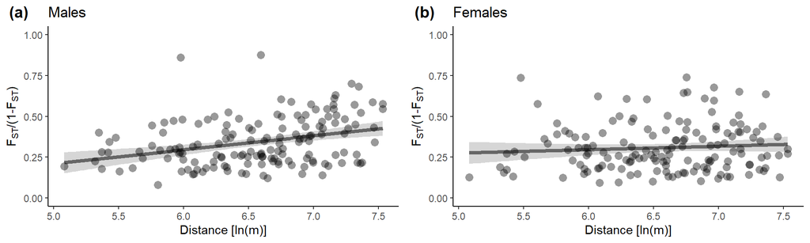

```r
# Plotting Female FST vs Distance scatterplot w/ regression line
p1 <- ggplot(fig3df,aes(Geo,Gen_F)) +
  geom_smooth(method = "lm",size = 1.5,color = "grey40",fill = "grey60") +
  geom_point(alpha = 0.4,fill = "black",color = "black",size = 3,shape = 16) +
  ggtitle("Females") + xlab("Distance [ln(m)]") +
  ylab(expression(F[ST]*"/(1-"*F[ST]*")")) +
  coord_cartesian(ylim = c(0.00,1.00)) +
  theme(axis.line = element_line(color = "black"),
        panel.background = element_rect(fill = NA))

# Plotting Male FST vs Distance scatterplot w/ regression line
p2 <- ggplot(fig3df,aes(Geo,Gen_M)) +
  geom_smooth(method = "lm",size = 1.5,color = "grey40",fill = "grey60") +
  geom_point(alpha = 0.4,fill = "black",color = "black",size = 3,shape = 16) +
  ggtitle("Males") + xlab("Distance [ln(m)]") +
  ylab(expression(F[ST]*"/(1-"*F[ST]*")")) +
  coord_cartesian(ylim = c(0.00,1.00)) +
  theme(axis.line = element_line(color = "black"),
        panel.background = element_rect(fill = NA))

# Combining figures side-by-side into one figure
ggarrange(p2,p1,labels = c("(a)","(b)"))
```

This is compared with the original **Figure 3**.

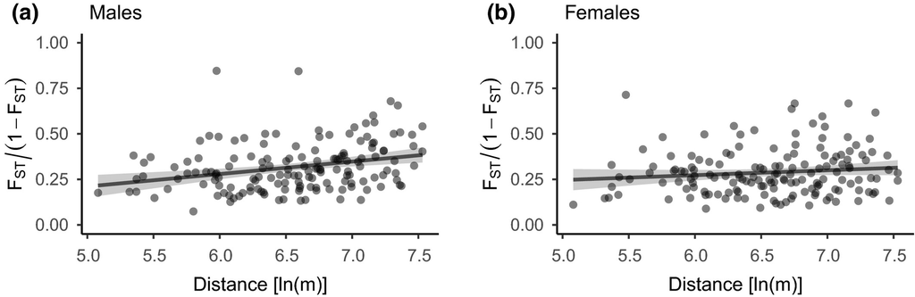

To continue with the spatial autocorrelation, I also replicated the correlograms. To do this, I made use of the final data file, *PairwiseRelatedness_allAdultDyads_2012.xlsx*. This table uses a Queller and Goodnight estimator of individual-individual pairwise relatedness. The autocorrelation analyses were conducted for these relatedness measurements in two ways for each sex. The first method was to correlate with pure geographic distance as calculated in the Mantel Test, with the distances split into groups of distances at 385m intervals; the second method is to correlate with home-range distance, meaning how many home ranges are between the given populations (i.e., 0 = same home range, 1 = adjacent ranges, 2 = one range inbetween, etc.).

The autocorrelation coefficient can be found by using the mean relatedness value r calculated in the *PairwiseRelatedness_allAdultDyads_2012.xlsx* table.

First, I’ll define a simple helper function to take in a full Group name (e.g., “BALAM”, “BOLAS”) and convert it to the shortened version (e.g., “BAL”, “BOL”).

```r
groupnames <- data.frame(A = c("BALAM","BOLAS","MOTIEPA","PAKAL","UNITES"),
                         B = c("BAL","BOL","MOT","PAK","UTS"))
groupfull <- function(n){
  # Function to turn an abbreviated group name into the full group name

  # Arguments:
  # n = abbreviated group name, in 3-letter format

  # Outputs:
  # Full group name (if a longer name exists)

  if(!(n %in% groupnames$B)){return(n)}
  else{
    return(groupnames[[1]][which(groupnames[[2]] == n)])
  }
}
```

Next, I define a function to take two groups and define a “distance group” as 0 if the groups are the same, then group by every 385m. Note that this 385m grouping cutoff simply comes from the methods section in the original paper, and I do not attempt to replicate how they came to this cutoff.

```r
rel$DistGroup <- rep(NA,nrow(rel))

# Assign distance class to each pairwise dyad, based on geographic distance
for(i in 1:nrow(rel)){
  if(rel$Grp1[i] == rel$Grp2[i]){rel$DistGroup[i] <- 0}
  else{
    g1 <- groupfull(rel$Grp1[i])
    g2 <- groupfull(rel$Grp2[i])
    d <- exp(1)^fig3df$Geo[which(fig3df$G1 == g1 & fig3df$G2 == g2 |
                                   fig3df$G2 == g1 & fig3df$G1 == g2)]
    if(d <= 385){rel$DistGroup[i] <- 1}
    else if(d <= 770){rel$DistGroup[i] <- 2}
    else if(d <= 1155){rel$DistGroup[i] <- 3}
    else if(d <= 1540){rel$DistGroup[i] <- 4}
    else if(d <= 1925){rel$DistGroup[i] <- 5}
    else{rel$DistGroup[i] <- 6}
  }
}
```

Now, I can generate Correlograms for both sexes for all distance groups. I’ll also get a bootstrapped null distribution using permutations of the distance groups, and use that to plot the null hypothesis and 95% confidence intervals.

```r
fig4df <- data.frame(YF = 0:6,YM = 0:6,X = 0:6,
                     PF = 0:6,PM = 0:6,
                     MF = 0:6,MM = 0:6,
                     F975 = 0:6,F025 = 0:6,M975 = 0:6,M025 = 0:6)
N <- 2000 # Number of iterations

# Get data to plot in correlogram

# Loop over each sex
for(s in c("FF","MM")){

  # Loop over all geographic distance classes
  for(g in 0:6){
    # cat("\nGroup #",g,"\n")
    bootF <- rep(NA,(N-1))
    bootM <- rep(NA,(N-1))
    di <- rel$QGR[which(rel$DistGroup == g & rel$SexDyadType == s)]

    # Permute N = 2,000 times
    for(i in 1:N){
      # cat("\rBootstrap ",i,"/",N,sep = "")

      # Get mean relatedness correlation r
      if(i == 1){
        if(s == "FF"){fig4df$YF[g + 1] <- mean(di,na.rm = T)}
        if(s == "MM"){fig4df$YM[g + 1] <- mean(di,na.rm = T)}
      }else{ # Get permuted distribution for the purpose of generating CIs
        set.seed(i)
        di <- rel %>% mutate(DistGroup = sample(DistGroup)) %>%
          filter(DistGroup == g & SexDyadType == s) %>% select(QGR)
        if(s == "FF"){bootF[i - 1] <- mean(di$QGR,na.rm = T)}
        if(s == "MM"){bootM[i - 1] <- mean(di$QGR,na.rm = T)}
      }
    }

    # Assign values for Females
    if(s == "FF"){
      fig4df$MF[g + 1] <- mean(bootF)
      fig4df$F975[g + 1] <- quantile(bootF,0.975,na.rm = T)
      fig4df$F025[g + 1] <- quantile(bootF,0.025,na.rm = T)
      if(fig4df$YF[g + 1] >= 0 | is.na(fig4df$YF[g + 1])){
        fig4df$PF[g + 1] <- length(which(bootF > fig4df$YF[g + 1]))/length(bootF)}
      else{fig4df$PF[g + 1] <- length(which(bootF < fig4df$YF[g + 1]))/length(bootF)}
    }

    # Assign values for Males
    if(s == "MM"){
      fig4df$MM[g + 1] <- mean(bootM)
      fig4df$M975[g + 1] <- quantile(bootM,0.975,na.rm = T)
      fig4df$M025[g + 1] <- quantile(bootM,0.025,na.rm = T)
      if(fig4df$YM[g + 1] >= 0 | is.na(fig4df$YF[g + 1])){
        fig4df$PM[g + 1] <- length(which(bootM > fig4df$YM[g + 1]))/length(bootM)}
      else{fig4df$PM[g + 1] <- length(which(bootM < fig4df$YM[g + 1]))/length(bootM)}
    }
  }
}

fig4df$SigOM <- (fig4df$YM > fig4df$M975)
fig4df$SigUM <- (fig4df$YM < fig4df$M025)
fig4df$SigOF <- (fig4df$YF > fig4df$F975)
fig4df$SigUF <- (fig4df$YF < fig4df$F025)
```

And this will generate the plots for relatedness r by distance group.

```r
# Prepare correlogram plots for geographic distance classes

# Correlogram for males
p2a <- ggplot(data = fig4df,aes(X)) +
  geom_line(aes(y = MM),size = 1,color = "grey") +
  geom_line(aes(y = M975),size = 1,color = "grey",linetype = "dashed") +
  geom_line(aes(y = M025),size = 1,color = "grey",linetype = "dashed") +
  geom_line(aes(y = YM),size = 1,color = "black") +
  geom_point(aes(y = (YM + 0.03),color = SigOM),shape = 42,size = 6) +
  geom_point(aes(y = (YM - 0.03),color = SigUM),shape = 42,size = 6) +
  coord_cartesian(ylim = c(-0.4,0.4),xlim = c(-0.2,6.2)) +
  scale_color_manual(values = c("white","black")) +
  theme(axis.line = element_line(color = "black"),
        panel.background = element_rect(fill = NA),
        legend.position = "none") +
  ggtitle("Males - Euclidean Distance Classes") +
  xlab("Distance Class (m)") + ylab("Correlation (r)") +
  scale_y_continuous(breaks = seq(-0.4,0.4,0.1),expand = c(0,0)) +
  scale_x_continuous(breaks = seq(0,6),
                     labels = c("0",
                                expression(atop(">0,",paste(""<="385"))),
                                expression(atop(">385,",paste(""<="770"))),
                                expression(atop(">770,",paste(""<="1155"))),
                                expression(atop(">1155,",paste(""<="1540"))),
                                expression(atop(">1540,",paste(""<="1925"))),
                                ">1925"))

# Correlogram for females
p2b <- ggplot(data = fig4df,aes(X)) + geom_line(aes(y = YF)) +
  geom_line(aes(y = MF),size = 1,color = "grey") +
  geom_line(aes(y = F975),size = 1,color = "grey",linetype = "dashed") +
  geom_line(aes(y = F025),size = 1,color = "grey",linetype = "dashed") +
  geom_line(aes(y = YF),size = 1,color = "black") +
  geom_point(aes(y = (YF + 0.03),color = SigOF),shape = 42,size = 6) +
  geom_point(aes(y = (YF - 0.03),color = SigUF),shape = 42,size = 6) +
  coord_cartesian(ylim = c(-0.4,0.4),xlim = c(-0.2,6.2)) +
  scale_color_manual(values = c("white","black")) +
  theme(axis.line = element_line(color = "black"),
        panel.background = element_rect(fill = NA),
        legend.position = "none") +
  ggtitle("Females - Euclidean Distance Classes") +
  xlab("Distance Class (m)") + ylab("Correlation (r)") +
  scale_y_continuous(breaks = seq(-0.4,0.4,0.1),expand = c(0,0)) +
  scale_x_continuous(breaks = seq(0,6),
                     labels = c("0",
                                expression(atop(">0,",paste(""<="385"))),
                                expression(atop(">385,",paste(""<="770"))),
                                expression(atop(">770,",paste(""<="1155"))),
                                expression(atop(">1155,",paste(""<="1540"))),
                                expression(atop(">1540,",paste(""<="1925"))),
                                ">1925"))
```

I can do a similar analysis using number of home ranges between groups, rather than geographic distance. This number of home ranges can be calculated using a function to take coordinates and output a list of neighbors, such as the `graph2nb` function in the `spdep` package. Below is a visual representation of the connection of points that I used for the home range distance calculations, showing how each group is connected and how many ranges are between each pairwise comparison, represented by edges.

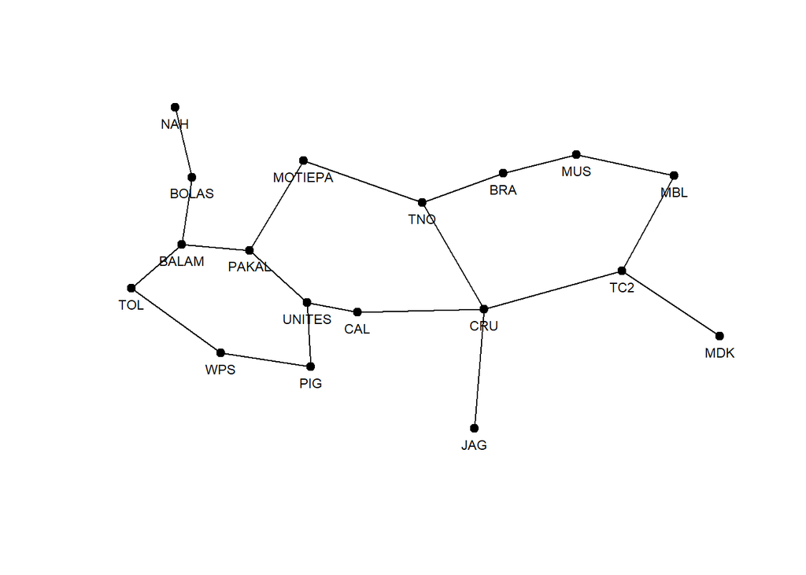

```r
# Convert coordinates to special coordinate object
coords2 <- coords[order(coords$Group),]
coords2$GrpNum <- 1:18
coordinates(coords2) <- ~X+Y

# Get neighbors from coordinates
neib <- graph2nb(relativeneigh(coords2),row.names = coords2@data$Group,sym = TRUE)

# Plot graph showing neighbors
plot(neib,coords2,pch = 19,
     ylim = c(min(coords2@coords[,2] - 50),max(coords2@coords[,2])))
# Label groups on graph
text(coords2@coords[,1],(coords2@coords[,2] - 50),labels = coords2@data$Group,
     cex = 0.7)
```

```r
# Get number of steps from between groups
lags <- nblag(neib,8)
```

From this graph, I can get the number of steps between two regions with the following function:

```r
GroupDist <- function(Grp1,Grp2){
  # Function to get number of steps between groups from the neighbor objects
  # obtained above

  # Arguments:
  # Grp1 = Pairwise Group 1
  # Grp2 = Pairwise Group 2

  # Outputs:
  # Steps from Group 1 to Group 2

  if(Grp1 == Grp2){return(0)}
  Grp1 <- groupfull(Grp1)
  Grp2 <- groupfull(Grp2)
  n1 <- coords2@data$GrpNum[which(coords2@data$Group == Grp1)]
  n2 <- coords2@data$GrpNum[which(coords2@data$Group == Grp2)]
  for(i in 1:8){
    if(n2 %in% lags[[i]][n1][[1]]){return(i)}
    else{next}
  }
}
```

Now, I’ll assign each dyad in *PairwiseRelatedness_allAdultDyads_2012.xlsx* to a new Distance Group based on number of home ranges, and I’ll perform the same analysis as above, generating a new correlogram based on these new groupings.

```r
rel$RangeDist <- rep(NA,2080)
for(i in 1:length(rel$Grp1)){
  rel$RangeDist[i] <- GroupDist(rel$Grp1[i],rel$Grp2[i])
}

fig4bdf <- data.frame(YF = 0:6,YM = 0:6,X = 0:6,
                     PF = 0:6,PM = 0:6,
                     MF = 0:6,MM = 0:6,
                     F975 = 0:6,F025 = 0:6,M975 = 0:6,M025 = 0:6)

# Same process for generating correlogram data as before, but this time using
# home range distance classes

N <- 2000

for(s in c("FF","MM")){
  for(g in 0:6){
    # cat("\nGroup #",g,"\n")
    bootF <- rep(NA,(N-1))
    bootM <- rep(NA,(N-1))
    di <- rel$QGR[which(rel$DistGroup == g & rel$SexDyadType == s)]
    for(i in 1:N){
      # cat("\rBootstrap ",i,"/",N,sep = "")
      if(i == 1){
        if(s == "FF"){fig4bdf$YF[g + 1] <- mean(di,na.rm = T)}
        if(s == "MM"){fig4bdf$YM[g + 1] <- mean(di,na.rm = T)}
      }else{
        set.seed(i)
        di <- rel %>% mutate(DistGroup = sample(DistGroup)) %>%
          filter(DistGroup == g & SexDyadType == s) %>% select(QGR)
        if(s == "FF"){bootF[i - 1] <- mean(di$QGR,na.rm = T)}
        if(s == "MM"){bootM[i - 1] <- mean(di$QGR,na.rm = T)}
      }
    }
    if(s == "FF"){
      fig4bdf$MF[g + 1] <- mean(bootF)
      fig4bdf$F975[g + 1] <- quantile(bootF,0.975,na.rm = T)
      fig4bdf$F025[g + 1] <- quantile(bootF,0.025,na.rm = T)
      if(fig4bdf$YF[g + 1] >= 0 | is.na(fig4bdf$YF[g + 1])){
        fig4bdf$PF[g + 1] <- length(which(bootF > fig4bdf$YF[g + 1]))/length(bootF)}
      else{fig4bdf$PF[g + 1] <- length(which(bootF < fig4bdf$YF[g + 1]))/length(bootF)}
    }
    if(s == "MM"){
      fig4bdf$MM[g + 1] <- mean(bootM)
      fig4bdf$M975[g + 1] <- quantile(bootM,0.975,na.rm = T)
      fig4bdf$M025[g + 1] <- quantile(bootM,0.025,na.rm = T)
      if(fig4bdf$YM[g + 1] >= 0 | is.na(fig4bdf$YF[g + 1])){
        fig4bdf$PM[g + 1] <- length(which(bootM > fig4bdf$YM[g + 1]))/length(bootM)}
      else{fig4bdf$PM[g + 1] <- length(which(bootM < fig4bdf$YM[g + 1]))/length(bootM)}
    }
  }
}

fig4bdf$SigOM <- (fig4bdf$YM > fig4bdf$M975)
fig4bdf$SigUM <- (fig4bdf$YM < fig4bdf$M025)
fig4bdf$SigOF <- (fig4bdf$YF > fig4bdf$F975)
fig4bdf$SigUF <- (fig4bdf$YF < fig4bdf$F025)
```

Based on the above functions, I also want to get p-values for each of my distance classes compared to the null, which can be calculated by comparison of the calculated mean correlations with the bootstrap null distribution. These calculations are included above.

And this is the code for the correlograms based on home range distance.

```r
# Prepare correlogram plots for geographic distance classes

# Correlogram for males
p2c <- ggplot(data = fig4bdf,aes(X)) +
  geom_line(aes(y = MM),size = 1,color = "grey") +
  geom_line(aes(y = M975),size = 1,color = "grey",linetype = "dashed") +
  geom_line(aes(y = M025),size = 1,color = "grey",linetype = "dashed") +
  geom_line(aes(y = YM),size = 1,color = "black") +
  geom_point(aes(y = (YM + 0.03),color = SigOM),shape = 42,size = 6) +
  geom_point(aes(y = (YM - 0.03),color = SigUM),shape = 42,size = 6) +
  coord_cartesian(ylim = c(-0.4,0.4),xlim = c(-0.2,8.2)) +
  scale_color_manual(values = c("white","black")) +
  theme(axis.line = element_line(color = "black"),
        panel.background = element_rect(fill = NA),
        legend.position = "none") +
  ggtitle("Males - Home Range Distance Classes") +
  xlab("Dyadic Home Range Distance Class") + ylab("Correlation (r)") +
  scale_y_continuous(breaks = seq(-0.4,0.4,0.1),expand = c(0,0)) +
  scale_x_continuous(breaks = seq(0,8))

# Correlogram for females
p2d <- ggplot(data = fig4bdf,aes(X)) + geom_line(aes(y = YF)) +
  geom_line(aes(y = MF),size = 1,color = "grey") +
  geom_line(aes(y = F975),size = 1,color = "grey",linetype = "dashed") +
  geom_line(aes(y = F025),size = 1,color = "grey",linetype = "dashed") +
  geom_line(aes(y = YF),size = 1,color = "black") +
  geom_point(aes(y = (YF + 0.03),color = SigOF),shape = 42,size = 6) +
  geom_point(aes(y = (YF - 0.03),color = SigUF),shape = 42,size = 6) +
  coord_cartesian(ylim = c(-0.4,0.4),xlim = c(-0.2,8.2)) +
  scale_color_manual(values = c("white","black")) +
  theme(axis.line = element_line(color = "black"),
        panel.background = element_rect(fill = NA),
        legend.position = "none") +
  ggtitle("Females - Home Range Distance Classes") +
  xlab("Dyadic Home Range Distance Class") + ylab("Correlation (r)") +
  scale_y_continuous(breaks = seq(-0.4,0.4,0.1),expand = c(0,0)) +
  scale_x_continuous(breaks = seq(0,8))
```

Now, displaying all correlograms in one figure:

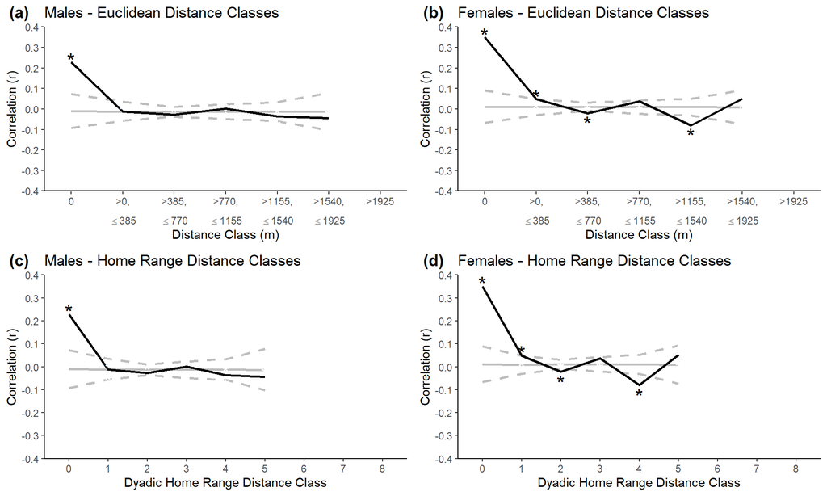

```r
ggarrange(p2a,p2b,p2c,p2d,ncol = 2,nrow = 2,labels = c("(a)","(b)","(c)","(d)"))
```

This is compared with the original **Figure 4**.

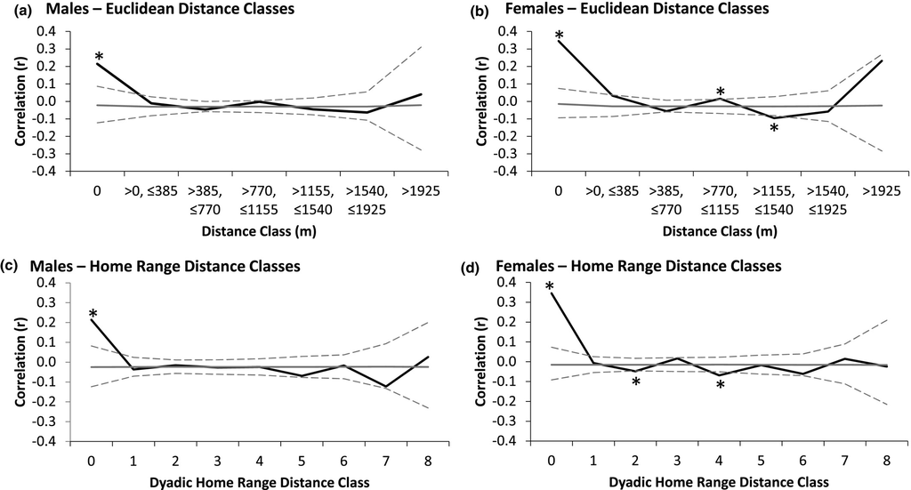

## 2.3 Relatedness Patterns

The final analysis I will reproduce is the analysis of the relatedness between individuals across different populations. First, I got a measure of mean within- group relatedness for same-sex dyads. I did this by getting all same-sex dyads and finding the overall mean of all within-group and between-group dyads for each sex. I could also find Confidence Intervals by randomly resampling from each of the same-sex dyad sets, with replacement, with 10,000 bootstrap replicates.

```r
rmeanM <- rel %>% filter(SexDyadType == "MM" & Grp1 == Grp2) %>%
  select(QGR)
rmeanF <- rel %>% filter(SexDyadType == "FF" & Grp1 == Grp2) %>%
  select(QGR)
rbetM <- rel %>% filter(SexDyadType == "MM" & Grp1 != Grp2) %>%
  select(QGR)
rbetF <- rel %>% filter(SexDyadType == "FF" & Grp1 != Grp2) %>%
  select(QGR)

N <- 10000 # Iterate 10,000 times

bootwM <- rep(NA,N)
bootwF <- rep(NA,N)
bootbM <- rep(NA,N)
bootbF <- rep(NA,N)
for(n in 1:N){
  # cat("\rBootstrap rep ",n,"/",N,sep = "")

  # Get mean relatedness for each home range distance class
  set.seed(n)
  bootwM[n] <- mean(sample(rmeanM$QGR,replace = TRUE))
  bootwF[n] <- mean(sample(rmeanF$QGR,replace = TRUE))
  bootbM[n] <- mean(sample(rbetM$QGR,replace = TRUE))
  bootbF[n] <- mean(sample(rbetF$QGR,replace = TRUE))
}

# Get p-values for comparisons of within- vs. between-group mean relatedness,
# as well as p-values for males vs. females relatedness within and between groups
pM <- (length(which(bootwM < mean(rbetM$QGR))) +
         length(which(bootbM > mean(rmeanM$QGR))))/length(c(bootwM,bootbM))
pF <- (length(which(bootwF < mean(rbetF$QGR))) +
         length(which(bootbF > mean(rmeanF$QGR))))/length(c(bootwF,bootbF))
pW <- (length(which(bootwM < mean(rmeanF$QGR))) +
         length(which(bootwF > mean(rmeanM$QGR))))/length(c(bootwM,bootwF))
pB <- (length(which(bootbM < mean(rbetF$QGR))) +
         length(which(bootbF > mean(rbetM$QGR))))/length(c(bootbM,bootbF))

cat("\nMean Within-population relatedness in Males   :",mean(rmeanM$QGR))
```

```
##
## Mean Within-population relatedness in Males   : 0.2276667
```

```r
cat(" (95% CI = ",quantile(bootwM,0.025)," to ",quantile(bootwM,0.975),")\n",sep = "")
```

```
##  (95% CI = 0.09974792 to 0.36225)
```

```r
cat("Mean Within-population relatedness in Females :",mean(rmeanF$QGR))
```

```
## Mean Within-population relatedness in Females : 0.3503478
```

```r
cat(" (95% CI = ",quantile(bootwF,0.025)," to ",quantile(bootwF,0.975),")\n",sep = "")
```

```
##  (95% CI = 0.2396511 to 0.4564826)
```

```r
cat("Mean Between-population relatedness in Males  :",mean(rbetM$QGR))
```

```
## Mean Between-population relatedness in Males  : -0.01997716
```

```r
cat(" (95% CI = ",quantile(bootbM,0.025)," to ",quantile(bootbM,0.975),")\n",sep = "")
```

```
##  (95% CI = -0.03796999 to -0.001732995)
```

```r
cat("Mean Between-population relatedness in Females:",mean(rbetF$QGR))
```

```
## Mean Between-population relatedness in Females: -0.003042834
```

```r
cat(" (95% CI = ",quantile(bootbF,0.025)," to ",quantile(bootbF,0.975),")\n",sep = "")
```

```
##  (95% CI = -0.01866573 to 0.01280272)
```

```r
cat("\nP-value of mean relatedness between populations vs within groups",
    "(males) =",pM)
```

```
##
## P-value of mean relatedness between populations vs within groups (males) = 0
```

```r
cat("\nP-value of mean relatedness between populations vs within groups",
    "(females) =",pF)
```

```
##
## P-value of mean relatedness between populations vs within groups (females) = 0
```

```r
cat("\nP-value of mean relatedness between males vs females (within groups) =",
    pW)
```

```
##
## P-value of mean relatedness between males vs females (within groups) = 0.97425
```

```r
cat("\nP-value of mean relatedness between males vs females (between groups) =",
    pB)
```

```
##
## P-value of mean relatedness between males vs females (between groups) = 0.9742
```

There was a significant difference in mean relatedness within groups vs between groups in both males and females (p < 0.0001 in both cases), and there was no significant difference in relatedness between males and females either within or between groups (p > 0.9 in both cases). This matches the results obtained from the original paper.

The next step of the analysis is to determine if within-group and between-group relatedness is significantly different, as well relatedness between the sexes. This is achieved by performing random permutation tests.

To get a p-value for within-group vs. between-group relatedness, I can generate a permutation distribution by randomizing the groups of each individual, then recalculating means for within-group and between-group relatedness.

```r
N <- 10000

bootwg <- rep(NA,N)
bootbg <- rep(NA,N)
bootM <- rep(NA,N)
bootF <- rep(NA,N)
for(i in 1:N){
  # cat("\rBootstrap rep ",i,"/",N,sep = "")
  set.seed(i)

  relG <- rel
  relG$Grp1 <- sample(relG$Grp1)
  relG$Grp2 <- sample(relG$Grp2)
  relGw <- relG %>% filter(Grp1 == Grp2)
  relGb <- relG %>% filter(Grp1 != Grp2)
  bootwg[i] <- mean(relGw$QGR)
  bootbg[i] <- mean(relGb$QGR)

  relS <- rel
  relS$SEX1 <- sample(relS$SEX1)
  relS$SEX2 <- sample(relS$SEX2)
  relSm <- relS %>% filter(SEX1 == "M" & SEX2 == "M" & Grp1 == Grp2)
  relSf <- relS %>% filter(SEX1 == "F" & SEX2 == "F" & Grp1 == Grp2)
  bootM[i] <- mean(relSm$QGR)
  bootF[i] <- mean(relSf$QGR)
}

win_btw <- mean(rel[["QGR"]][which(rel$Grp1 == rel$Grp2)]) -
  mean(rel[["QGR"]][which(rel$Grp1 != rel$Grp2)])
wbDist <- bootwg - bootbg
m_f <- mean(rel[["QGR"]][which(rel$SEX1 == "M" & rel$SEX2 == "M" & rel$Grp1 == rel$Grp2)]) -
  mean(rel[["QGR"]][which(rel$SEX1 == "F" & rel$SEX2 == "F" & rel$Grp1 == rel$Grp2)])
mfDist <- bootM - bootF
pwb <- (length(which(wbDist >= abs(win_btw))) +
          length(which(wbDist <= -abs(win_btw))))/10000
pmf <- (length(which(mfDist >= abs(m_f))) +
          length(which(mfDist <= -abs(m_f))))/10000
cat("\n\n")
```

```r
cat("P-value of Difference in mean of Within-population vs",
    "Between-population relatedness :",pwb)
```

```
## P-value of Difference in mean of Within-population vs Between-population relatedness : 0
```

```r
cat("\n")
```

```r
cat("P-value of Difference in mean of Male vs",
    "Female relatedness within populations :",pmf)
```

```
## P-value of Difference in mean of Male vs Female relatedness within populations : 0.1826
```

The final analysis is between to determine the proportion of “close relatives” in each home range distance class of dyads.

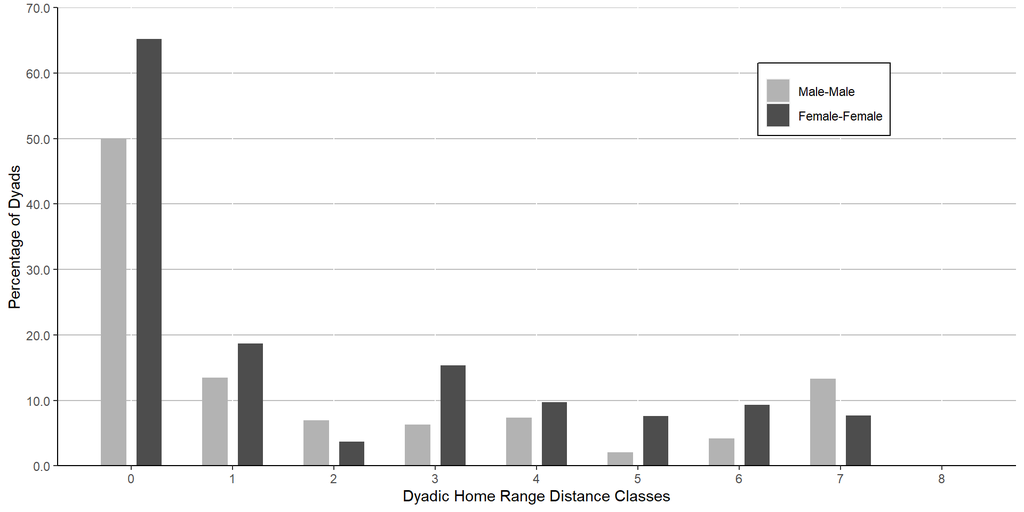

```r
# Get data for plotting mean relatedness vs. distance class
fig5df <- data.frame(Y = rep(NA,18),S = rep(NA,18),X = rep(NA,18))
for(i in 0:8){
  reliM <- rel %>% filter(RangeDist == i & SexDyadType == "MM")
  reliF <- rel %>% filter(RangeDist == i & SexDyadType == "FF")
  rMi <- 100*(length(which(reliM$QGR >= 0.25))/length(reliM$QGR))
  rFi <- 100*(length(which(reliF$QGR >= 0.25))/length(reliF$QGR))
  fig5df$Y[(2*(i+1)-1)] <- rMi
  fig5df$S[(2*(i+1)-1)] <- "MM"
  fig5df$X[(2*(i+1)-1)] <- i
  fig5df$Y[(2*(i+1))] <- rFi
  fig5df$S[(2*(i+1))] <- "FF"
  fig5df$X[(2*(i+1))] <- i
}

fig5df$S <- factor(fig5df$S,levels = c("MM","FF"))

# Plot mean relatedness per distance class for males and females
ggplot(fig5df,aes(X,Y,fill = S)) +
  geom_bar(stat = "identity",position = position_dodge(0.7),width = 0.5) +
  scale_fill_grey(start = 0.7,end = 0.3,labels = c("Male-Male","Female-Female")) +
  theme(axis.line = element_line(color = "black"),
        panel.background = element_rect(fill = NA),
        panel.grid.major.y = element_line(color = "grey"),
        legend.title = element_blank(),
        legend.position = c(0.8,0.8),
        legend.background = element_rect(color = "black")) +
  scale_y_continuous(breaks = seq(0,70,10),expand = c(0,0),
                     labels = function(x) format(x,nsmall = 1)) +
  scale_x_continuous(breaks = seq(0,8)) +
  coord_cartesian(ylim = c(0,70)) +
  xlab("Dyadic Home Range Distance Classes") + ylab("Percentage of Dyads")
```

This is compared with the original **Figure 5**.

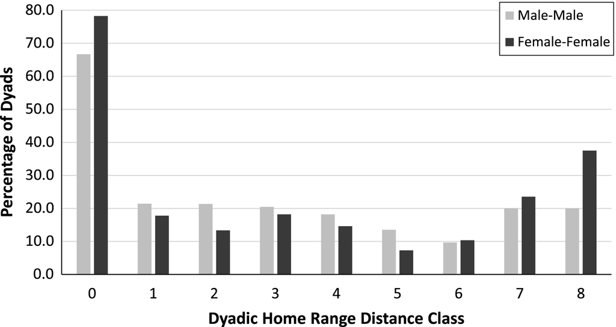

```r
# Perform multiple chi-square tests for
chisq.test(fig5df$Y[which(fig5df$S == "FF")])      # All distance classes in females
```

```
##
##  Chi-squared test for given probabilities
##
## data:  fig5df$Y[which(fig5df$S == "FF")]
## X-squared = 200.48, df = 8, p-value < 2.2e-16
```

```r
chisq.test(fig5df$Y[which(fig5df$S == "MM")])      # All distance classes in males
```

```
##
##  Chi-squared test for given probabilities
##
## data:  fig5df$Y[which(fig5df$S == "MM")]
## X-squared = 158.72, df = 8, p-value < 2.2e-16
```

```r
chisq.test(fig5df$Y[which(fig5df$S == "FF")][2:8]) # Only between classes in females
```

```
##
##  Chi-squared test for given probabilities
##
## data:  fig5df$Y[which(fig5df$S == "FF")][2:8]
## X-squared = 15.033, df = 6, p-value = 0.02
```

```r
chisq.test(fig5df$Y[which(fig5df$S == "MM")][2:8]) # Only between classes in males
```

```
##
##  Chi-squared test for given probabilities
##
## data:  fig5df$Y[which(fig5df$S == "MM")][2:8]
## X-squared = 14.539, df = 6, p-value = 0.02416
```

These $\chi^2$ tests reveal that the distribution of percentage of close relatives is very heavily skewed towards within-population pairwise comparisons in both males and females, with the p-values for both of these being < 2.2e-16. Conversely, the $\chi^2$ tests ignoring the within-population distance class (0) show no significance in either sex (male p-value = 0.024, p > 0.01; female p-value = 0.02, p > 0.01). This recapitulates the results found in the original paper.

# 3. Discussion

Overall, I feel that the results replicated in this project were fairly accurate to the results presented in the original paper. All of the analyses yielded results which largely resembled the results and figures in the original paper, but there were certainly several noticeable differences, and some of these differences are due to difficulties which arose during the replication. These issues, as well as my general impressions with the success of each analysis are discussed below.

## 3.0 General Considerations

I believe I did a decent job of getting the main point of the original paper; my conceptual understanding of the paper and its analyses is given in the introduction.

When running my analyses, I also needed to be sure to include a `set.seed()` argument to all of my functions which utilized random sampling. This was important in generating all of the permutation and bootstrapping distributions which were used for statistical testing. A `set.seed()` function is therefore included at the top of all relevant loops or functions. However, because of the randomness of the sampling, some of the values calculated, especially for p-values or confidence intervals, could be very slightly different.

Throughout the replication, I also often performed fewer permutation or bootstrap replicates than were used in the original paper. This was done purely because my computer was having a difficult time handling long computation times associated with the many thousands of replicates. It is possible that this will lead to different null or sampling distributions, but visual inspection of the plot and values obtained seem to suggest that the reduced number of replications did not significantly alter the results.

The first two figures in the original paper were maps. The first figure showed the geospatial location of all groups, while the second figure showed many migration events. However, the only data relating to mapping included in the public data sets were coordinates of the centroid of each group’s home range, which was not enough to recreate these figures. Additionally, the figures are largely based on physical observations, such as noticing that one individual which was known to have previously been in one group was spotted in a different group at a later sampling/observation period. I did not feel that these observations were replicable without simply reading from the observations in the supplementary data. Therefore, I decided to skip these figures when replicating the paper.

Despite excluding the first two figures, I believe that I still had plenty of material to work with for conducting my replication analyses.

## 3.1 Validating Global $\small F_{ST}$

The first analysis was performed was the global $\small F_{ST}$ estimation for males and females separately. I immediately encountered a bit of difficutly as the estimation of $\small F_{ST}$ values was performed using the program `FSTAT`, which is a desktop program rather than an R program. However, digging into the documentation and publications related to `FSTAT`, I was able to find 1) the $\small F_{ST}$ estimator used is the Weir-Cockerham (or “WC”) estimator, and 2) there is an R package called `hierfstat` which is the successor of `FSTAT` and implements a function `wc()` which calculates the WC $\small F_{ST}$ estimator.

With the knowledge of the estimator used in the original paper, I felt confident in continuing with this analysis. However, the genotype data as given in the *GenotypeData_Dryad.csv* file needed to be converted to a specific format so it could be analyzed by `wc()`. This analysis was performed accurately, but I do note that at this point I was no longer working with the raw data.

## 3.2 Difficulties with Spatial Autocorrelation Analysis

The next step in the analysis was to perform spatial autocorrelation analyses. To do this, I needed to find a correlation between $F_{ST}/(1 - F_{ST})$. My initial instinct was to simply perform this analysis using the same `wc()` function as in the previous section. However, performing the analysis this way created a problem as one term of the WC estimator involves dividing by $\bar{n} - 1$, and if both populations being compaired pairwise only contain one adult of the sex of interest, this will lead to an incorrect estimator. Interestingly, in this case the `wc()` function returns a 0 rather than an error, so I at first thought that my calculations were simply very far off rather than wrong, and it was not until further investigation that I discovered the root of the problem.

Now knowing that the WC estimator would not work for calculating $\small F_{ST}$, I tried to find another estimator to use instead. However, this proved significantly more difficult than anticipated. The first confusion arose from the documentation for `GenAlEx`, the program used for performing the correlation analysis and which also did not have an R package equivalent. Additionally, a Mantel Test, rather than the standard linear correlation, was used. The GenAlEx tutorials, which contained information on the formulas used, included information for calculating the correlation coefficient from several calculations of genetic distance. For this reason, I tried approximating $\small F_{ST}$ by Nei’s D and AMOVA, other methods for estimating genetic distance, and both of which require very involved calculations to manually replicate in R. Unfortunately, neither of these methods yielded results similar to the original paper. It was not until delving deeper into the GenAlEx tutorials that I found the estimator for $\small F_{ST}$ using $\frac{H_T - \bar{H}_e}{H_T}$, where the heterozygozities are calculated using observed allele frequencies. This yielded results which were significantly closer to the original, but were still not an exact match. Due to the somewhat unclear documentation for GenAlEx, I believe that this difference could be due to differences in how exactly $\small F_{ST}$ was estimated.

## 3.3 Distance Group Discrepancies

To generate the correlograms, it was necessary to split the relatedness data into groups. The first grouping was done by linear cartesian distance between the center of the home ranges. Strangely, this yielded 5 distance groups for me, but in the original paper there were 6 distance groups (not including the “0” distance group for within-group dyads). I am still very unsure why this difference arose because I took the straight-line distance directly from the coordinates given in *GeographicCoordinates.csv*, and I did not find any groups which were greater than 1925m apart. This leads to replicated correlograms which generally look quite similar to the original but differ at the higher-distance groups. Additionally, the location of the significant points in this method did not match the original paper, likely due to the same reason of missing the last distance group.

The second form of grouping was by determining the number of home ranges between any two groups. However, given just the coordinate data provided with the paper, I was unable to concretely determine how exactly groups touched, and how many group borders would need to be crossed to get from one group to another. For this reason, I employed a package called `spdep` which contains a several functions for getting neighbors from a list of coordinates. From these functions, I could generate a graph with edges between each of the home group centroids, and use the number of edges as a proxy for the number of home groups between two individuals in a dyad. I settled upon the neighbor-generating function that I ended up using, `graph2nb(relativeneigh())` somewhat arbitrarily simply because it yielded the correct maximum number of steps between the two farthest groups. However, I certainly recognize that this method of determining home range distance is likely different from the method originally used. Despite this, the correlograms based on home range distance look decently similar to the originals, and I suspect that differences in the exact values are likely due to differences in how home range distance was computed. Similarly to the previous analysis, this led to correlograms with different significant points than the original. Nevertheless, I believe the method I ultimately decided to use worked out pretty well for the analyses I was trying to replicate.

## 3.4 Issues Replicating “Close Relative” Determination

The final part of the analysis was to determine if the percentage of “close relatives” differed between within-group or between-group dyads. The program used in the original was `ML-relate` which was again, unfortunately, a desktop program which did not have an existing R package analogue. Additionally, reading through the documentation for the program as well as the paper describing it did not reveal any information which I could interpret or use. From my understanding, some sort of simulation was performed where genotypes were assigned to individuals and their relatedness was calculated from those simulations, then a likelihood test of the level of kinship (e.g., parent-offspring, half-sib, or full-sib) was performed to assess if it was likely that that kinship could have led to the observed relatedness. Sadly, the description of this methodology was not detailed enough for me to replicate. I therefore decided to use an extremely un-nuanced determination of kinship where I simply used the Queller-Goodnight relatedness estimator provided in the data and said that any individuals with a relatedness coefficient of 0.25 or greater were “closely related”. Obviously, this approach is significantly different from the one used in the original paper, and the results are not an extremely close match to the original. Having said that, the general trend in the distribution observed for percentage of close relatives per each distance group was actually still quite similar to the original.

## 3.5 Final Thoughts

This paper proved to be quite challenging for me to replicate faithfully. The most common and significant roadblocks came from programs used in the original paper which did not have a nice analogous R package. I struggled at times to correctly read the original documentation for these programs. For this reason, I feel that I likely performed some calculations using different formulae than the original paper, and I believe were the cause of several of the discrepancies in results that I observed. In general, I mostly struggled with getting the correct methods from the methods section of the original paper as well as the methods and documentation of the external software utilized, and this is the issue to which I dedicated the vast majority of my time.

The other main issue I ran into was with the results not matching up despite me being confident that I had the correct method (such as calculating $\small F_{ST}$ using the WC estimator). In these cases, I’m not entirely sure where the issue lay, and a thorough dive into the specifics of the original code after the project is done would likely illuminate some of these areas where I was confused.

Overall, this project was very helpful in giving me more experience with going directly to the primary literature and software documentation to get a better sense for what is going on behind the scenes for software I might use in the future. More importantly, this develops that skill which will be very useful for both writing my own code and using pre-created packages or software. This project definitely pushed me mentally and I found the experience very rewarding. I also learned a lot about several population genetics and quantitative ecology methods.